# Determining the Contribution of Osmotic Stress to the Antibacterial Properties of Honey

Ahmad Abdel-Azim

3/29/2019

Date Started: 3/19/2018  
Other Authors:  
- Salma Abdel-Azim  
- Gamal Abdel-Azim

### ABSTARCT

Researchers have repeatedly shown that honey possesses distinctive antimicrobial properties; however, there is uncertainty over which compounds in honey are responsible for these properties. In this research study, we sought to quantify the role of osmotic stress in honey and determine the efficacy of two types of honey: Manuka and raw pasture honey. Bacteria were sequentially cultured in sublethal concentrations of Manuka and raw pasture honey for five days. The role of osmotic stress as a contributor to the antibacterial properties of Manuka and raw pasture honey was quantified in the first culture and over five serial cultures. The growth levels of bacteria in honey were compared to growth levels in glucose, an osmotic control, to quantify the role of osmotic stress in the two types of honey. The results of this study indicate that in the first culture, the antibacterial impacts of Manuka and raw pasture honey were primarily attributable to osmotic stress. However, over five days of sequential transfers, both raw pasture honey and Manuka honey showed significant antibacterial properties beyond osmotic strength. It was established that the antibacterial properties of honey cannot be investigated based solely on the first culture. Serial transfers over several days should be employed to investigate the efficacy of honey as an antibacterial substance.

## Read in Data

```r
honeyGlu.d1 <- read.csv("Data/honeyGlucoseCd1.csv", header = T)
honeyGlu.d5 <- read.csv("Data/honeyGlucosetoCd5.csv", header = T)
```

## Day 1 Analysis

### Combined effect Day 1

Default: control as reference

```r
table (honeyGlu.d1$Culture)
```

```
 1
57
```

```r
honeyGlu.d1$Day <- as.numeric(as.character(honeyGlu.d1$Day))
honeyGlu.d1$StrCon <- factor(honeyGlu.d1$StrCon)

honeyGlu.d1$StrCon <- relevel(honeyGlu.d1$StrCon, ref = "Control")
od.lm.control.1 <- lm(OD ~ Day + StrCon, data = honeyGlu.d1)
summary(od.lm.control.1)
```

```
Call:
lm(formula = OD ~ Day + StrCon, data = honeyGlu.d1)

Residuals:
     Min       1Q   Median       3Q      Max
-0.15969 -0.04097  0.00200  0.05200  0.20333

Coefficients:
               Estimate Std. Error t value Pr(>|t|)
(Intercept)     1.82331    0.04173  43.695  < 2e-16 ***
Day            -0.03931    0.01391  -2.826  0.00706 **
StrConGlu16    -0.92469    0.06573 -14.067  < 2e-16 ***
StrConGlu6     -0.66802    0.06573 -10.163 4.05e-13 ***
StrConLocal140 -0.30450    0.13342  -2.282  0.02736 *
StrConLocal160 -0.38881    0.12206  -3.186  0.00266 **
StrConLocal180 -0.38450    0.13342  -2.882  0.00609 **
StrConLocal210 -0.57420    0.09440  -6.082 2.55e-07 ***
StrConLocal260 -0.89303    0.05251 -17.008  < 2e-16 ***
StrConManuka50 -0.23312    0.11128  -2.095  0.04196 *
StrConManuka60 -0.24612    0.10030  -2.454  0.01816 *
StrConManuka70 -0.33875    0.07868  -4.305 9.18e-05 ***
StrConManuka80 -0.71569    0.05015 -14.271  < 2e-16 ***
---
Signif. codes:  0 ‘***’ 0.001 ‘**’ 0.01 ‘*’ 0.05 ‘.’ 0.1 ‘ ’ 1

Residual standard error: 0.08797 on 44 degrees of freedom
Multiple R-squared:  0.9213,    Adjusted R-squared:  0.8999
F-statistic: 42.95 on 12 and 44 DF,  p-value: < 2.2e-16
```

Re-leveling the data with Glu6 as reference

```r
honeyGlu.d1$StrCon <- relevel(honeyGlu.d1$StrCon, ref = "Glu6")
od.lm.Glu6.1 <- lm(OD ~ StrCon, data = honeyGlu.d1)
summary(od.lm.Glu6.1)
```

```
Call:
lm(formula = OD ~ StrCon, data = honeyGlu.d1)

Residuals:
    Min      1Q  Median      3Q     Max
-0.1990 -0.0420  0.0020  0.0510  0.2033

Coefficients:
                Estimate Std. Error t value Pr(>|t|)
(Intercept)     1.076667   0.054592  19.722  < 2e-16 ***
StrConControl   0.707333   0.069054  10.243 2.44e-13 ***
StrConGlu16    -0.256667   0.077204  -3.325 0.001768 **
StrConLocal140  0.088333   0.086317   1.023 0.311608
StrConLocal160  0.043333   0.086317   0.502 0.618097
StrConLocal180  0.008333   0.086317   0.097 0.923518
StrConLocal210 -0.092917   0.064014  -1.451 0.153578
StrConLocal260 -0.244667   0.062244  -3.931 0.000289 ***
StrConManuka50  0.238333   0.086317   2.761 0.008307 **
StrConManuka60  0.225333   0.069054   3.263 0.002107 **
StrConManuka70  0.211333   0.069054   3.060 0.003719 **
StrConManuka80 -0.047667   0.062244  -0.766 0.447792
---
Signif. codes:  0 ‘***’ 0.001 ‘**’ 0.01 ‘*’ 0.05 ‘.’ 0.1 ‘ ’ 1

Residual standard error: 0.09456 on 45 degrees of freedom
Multiple R-squared:  0.9071,    Adjusted R-squared:  0.8843
F-statistic: 39.93 on 11 and 45 DF,  p-value: < 2.2e-16
```

Re-leveling the data with Glu16 as reference

```r
honeyGlu.d1$StrCon <- relevel(honeyGlu.d1$StrCon, ref = "Glu16")
od.lm.Glu16.1 <- lm(OD ~ Day + StrCon, data = honeyGlu.d1)
summary(od.lm.Glu16.1)
```

```
Call:
lm(formula = OD ~ Day + StrCon, data = honeyGlu.d1)

Residuals:
     Min       1Q   Median       3Q      Max
-0.15969 -0.04097  0.00200  0.05200  0.20333

Coefficients:
               Estimate Std. Error t value Pr(>|t|)
(Intercept)     0.89862    0.05791  15.518  < 2e-16 ***
Day            -0.03931    0.01391  -2.826 0.007057 **
StrConGlu6      0.25667    0.07183   3.573 0.000869 ***
StrConControl   0.92469    0.06573  14.067  < 2e-16 ***
StrConLocal140  0.62019    0.12621   4.914 1.28e-05 ***
StrConLocal160  0.53588    0.11582   4.627 3.27e-05 ***
StrConLocal180  0.54019    0.12621   4.280 9.95e-05 ***
StrConLocal210  0.35048    0.08895   3.940 0.000287 ***
StrConLocal260  0.03166    0.05833   0.543 0.590043
StrConManuka50  0.69156    0.10624   6.510 6.00e-08 ***
StrConManuka60  0.67856    0.09468   7.167 6.51e-09 ***
StrConManuka70  0.58594    0.07661   7.649 1.30e-09 ***
StrConManuka80  0.20900    0.05791   3.609 0.000782 ***
---
Signif. codes:  0 ‘***’ 0.001 ‘**’ 0.01 ‘*’ 0.05 ‘.’ 0.1 ‘ ’ 1

Residual standard error: 0.08797 on 44 degrees of freedom
Multiple R-squared:  0.9213,    Adjusted R-squared:  0.8999
F-statistic: 42.95 on 12 and 44 DF,  p-value: < 2.2e-16
```

### Predictive model for osm

11/22/18: no longer used due to actual measure of all concentration osm

```r
OsmVsMgperml <- read.csv("Data/OsmVsMgpermlData.csv", header = T)
OsmVsMgperml <- rbind(OsmVsMgperml[1:2,], OsmVsMgperml)
OsmVsMgperml$Solution <- as.character(OsmVsMgperml$Solution)
OsmVsMgperml$Solution[1:2] <- "Manuka honey"
OsmVsMgperml$Solution[3:4] <- "Local honey"
lm.OsmVsMgperml <- lm(mmol.per.kg ~ mgperml + Solution, data = OsmVsMgperml)
summary(lm.OsmVsMgperml)
```

```
Call:
lm(formula = mmol.per.kg ~ mgperml + Solution, data = OsmVsMgperml)

Residuals:
    Min      1Q  Median      3Q     Max
-38.333  -1.125  -0.250   1.000  47.667

Coefficients: (1 not defined because of singularities)
                       Estimate Std. Error t value Pr(>|t|)
(Intercept)           4.200e+02  1.656e+01  25.368 3.78e-08 ***
mgperml               4.641e+00  2.535e-01  18.309 3.59e-07 ***
SolutionLocal Honey  -5.123e+01  5.494e+01  -0.933    0.382
SolutionManuka honey -4.676e-13  2.341e+01   0.000    1.000
SolutionManuka Honey         NA         NA      NA       NA
---
Signif. codes:  0 ‘***’ 0.001 ‘**’ 0.01 ‘*’ 0.05 ‘.’ 0.1 ‘ ’ 1

Residual standard error: 23.41 on 7 degrees of freedom
Multiple R-squared:  0.9984,    Adjusted R-squared:  0.9976
F-statistic:  1415 on 3 and 7 DF,  p-value: 4.211e-10
```

Assigning Osmolality

```r
OsmVsMgperml$predicted.osm <- 430.46878 + 4.41526 * OsmVsMgperml$mgperml
predict.osm <- function(x) {430.46878 + 4.41526 * x}
honeyGlu.d1$predicted.osm <- 0
honeyGlu.d1[honeyGlu.d1$Conc >16 ,"predicted.osm"] <- predict.osm(honeyGlu.d1[honeyGlu.d1$Conc >16 ,"Conc"])
honeyGlu.d1[honeyGlu.d1$Conc ==16 ,"predicted.osm"] <- 1494.5997
honeyGlu.d1[honeyGlu.d1$Conc ==6 ,"predicted.osm"] <- 802
honeyGlu.d1[honeyGlu.d1$Conc ==0 ,"predicted.osm"] <- 420
```

### Osmalality within Treatment Analysis d1

- No Control
- No lethals
- ref = glu

```r
honeyGlu.d1.no.control <- honeyGlu.d1[honeyGlu.d1$Trt != 'Control',]
lm.osm.within.trt.d1 <- lm(OD ~ Day + Trt + predicted.osm%in%Trt, data = honeyGlu.d1.no.control)
summary(lm.osm.within.trt.d1)
```

```
Call:
lm(formula = OD ~ Day + Trt + predicted.osm %in% Trt, data = honeyGlu.d1.no.control)

Residuals:
      Min        1Q    Median        3Q       Max
-0.268515 -0.050153 -0.001465  0.060218  0.203333

Coefficients:
                          Estimate Std. Error t value Pr(>|t|)
(Intercept)              1.3953424  0.1477112   9.446    3e-12 ***
Day                     -0.0107335  0.0128907  -0.833 0.409438
TrtLocal                 0.7377006  0.3662986   2.014 0.050019 .
TrtManuka                2.1409106  0.6143579   3.485 0.001110 **
TrtGlu:predicted.osm    -0.0003706  0.0001213  -3.056 0.003765 **
TrtLocal:predicted.osm  -0.0008025  0.0002132  -3.764 0.000482 ***
TrtManuka:predicted.osm -0.0031212  0.0007733  -4.036 0.000208 ***
---
Signif. codes:  0 ‘***’ 0.001 ‘**’ 0.01 ‘*’ 0.05 ‘.’ 0.1 ‘ ’ 1

Residual standard error: 0.1029 on 45 degrees of freedom
Multiple R-squared:  0.7423,    Adjusted R-squared:  0.7079
F-statistic:  21.6 on 6 and 45 DF,  p-value: 9.192e-12
```

Separating the effect of osmotic strength and antimicrobials d1

```r
honeyGlu.d1.no.control <- honeyGlu.d1[honeyGlu.d1$Trt != 'Control',]
lm.osm.trt.d1 <- lm(OD ~ Day + Trt + predicted.osm, data = honeyGlu.d1.no.control)
summary(lm.osm.trt.d1)
```

```
Call:
lm(formula = OD ~ Day + Trt + predicted.osm, data = honeyGlu.d1.no.control)

Residuals:
      Min        1Q    Median        3Q       Max
-0.301606 -0.046706 -0.001185  0.076096  0.199156

Coefficients:
                Estimate Std. Error t value Pr(>|t|)
(Intercept)    1.3627153  0.1478311   9.218 4.14e-12 ***
Day            0.0216131  0.0080011   2.701 0.009577 **
TrtLocal       0.0304380  0.0718505   0.424 0.673769
TrtManuka      0.0163590  0.0650426   0.252 0.802514
predicted.osm -0.0003985  0.0001135  -3.512 0.000994 ***
---
Signif. codes:  0 ‘***’ 0.001 ‘**’ 0.01 ‘*’ 0.05 ‘.’ 0.1 ‘ ’ 1

Residual standard error: 0.114 on 47 degrees of freedom
Multiple R-squared:  0.6694,    Adjusted R-squared:  0.6413
F-statistic: 23.79 on 4 and 47 DF,  p-value: 8.438e-11
```

Plotting day 1 concentrations of local and Manuka (and glucose/LB)

```r
honeyGlu.d1.zeros <- read.csv("Data/honeyGlucoseCd1zeros.csv") # Adding lethals
library("Hmisc")

#tiff("./Final\ Figures/Fig.1.300.tiff", units = "in", width = 8, height = 5, res = 300)
par(mar = c(5,5,2,2))
Mconc <- honeyGlu.d1.zeros[honeyGlu.d1.zeros$Trt == "Manuka",]
plot(Mconc$Conc, Mconc$OD, ylim = c(-0.1,2), xaxt = "n", xlim = c(50, 270), pch=16, cex = 1.5, col= "dark orange", ylab = expression("Bacterial Growth (OD "[600]*")"), xlab = "Concentration in LB (mg/mL)")
axis(1, at = seq(50, 270, by = 20), cex.lab = 1.2, cex.axis = 1)
```

```r
minor.tick(nx=5, ny=4, tick.ratio=0.75)

Mconc.line <- tapply(Mconc$OD, Mconc$Conc, mean)
lines(as.numeric(names(Mconc.line)), Mconc.line, type='l', col="dark orange", lwd = 2, lty = 2)
```

```r
# Using linear model instead of avg
# lm.Mconc <- lm(OD ~ Conc, data = Mconc)
# lines(Mconc$Conc, predict(lm.Mconc), type='l', col="dark orange", lwd = 3, lty = 3)

Lconc <- honeyGlu.d1.zeros[honeyGlu.d1.zeros$Trt == "Local",]
points(Lconc$Conc, Lconc$OD, pch=16, cex = 1.5, col= "dark green")
lm.Lconc <- lm(OD ~ Conc, data = Lconc)
lines(Lconc$Conc, predict(lm.Lconc), type='l', col= "dark green", lwd = 2, lty = 2)
```

```r
avgControl.d1 <- mean(honeyGlu.d1.zeros[honeyGlu.d1.zeros$Trt == "Control", "OD"])
lines(seq(40, 270, 10), rep(avgControl.d1, 24), type='l', col= "black", lwd = 2, lty = 2)

glu.lm <- lm(OD ~ Conc, data = honeyGlu.d1.zeros[honeyGlu.d1.zeros$Trt == "Glu",])
avgGlu6.d1 <- mean(honeyGlu.d1.zeros[honeyGlu.d1.zeros$StrCon == "Glu6", "OD"])
avgGlu16.d1 <- mean(honeyGlu.d1.zeros[honeyGlu.d1.zeros$StrCon == "Glu16", "OD"])
points(10*(4.5:27), predict(glu.lm, newdata = data.frame(Conc = 4.5:27)), type='l', col= "blue", lwd = 3, lty = 1)
```

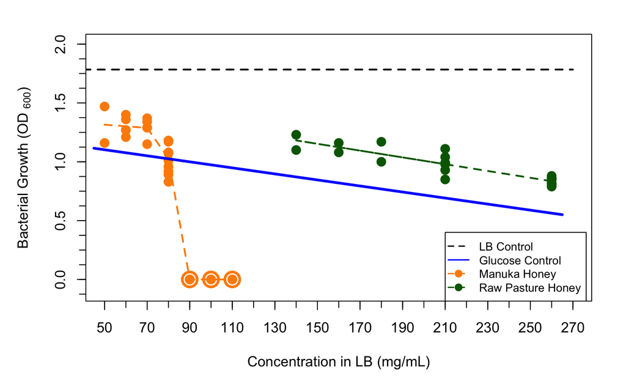

```r
symbols(x=c(90,100, 110), y=c(0,0,0), circles=c(3.5,3.5,3.5), add=T, inches=F, fg = "dark orange", lwd = 3)

legend(210, .4, pch = c(NA,NA,16,16), lty = c(2,1,2,2), lwd = 1.5, col = c("black","blue", "dark orange", "dark green"),
       legend=c("LB Control","Glucose Control", "Manuka Honey", "Raw Pasture Honey"), cex = 0.8, pt.cex = 1.2)
```

## Day 1-5 Analysis (without 48 hr strain)

### Combined effect 5 days

Default: control as reference

```r
table (honeyGlu.d5$Culture)
```

```
 1  2  3  4  5
57 53 20 21 22
```

```r
honeyGlu.d5.no.48 <- honeyGlu.d5
honeyGlu.d5 <- honeyGlu.d5[honeyGlu.d5$OD.Hrs == 24 & honeyGlu.d5$Comments == "",]
honeyGlu.d5$Day <- as.numeric(as.character(honeyGlu.d5$Day))
honeyGlu.d5$StrCon <- factor(honeyGlu.d5$StrCon)
#honeyGlu.d5$Day <- factor(honeyGlu.d5$Day)
honeyGlu.d5$StrCon <- relevel(honeyGlu.d5$StrCon, ref = "Control")
od.lm.control.5 <- lm(OD ~ Day + StrCon, data = honeyGlu.d5)
summary(od.lm.control.5)
```

```
Call:
lm(formula = OD ~ Day + StrCon, data = honeyGlu.d5)

Residuals:
    Min      1Q  Median      3Q     Max
-0.9602 -0.1553  0.0369  0.2175  0.7116

Coefficients:
               Estimate Std. Error t value Pr(>|t|)
(Intercept)     1.87866    0.10625  17.682  < 2e-16 ***
Day            -0.02888    0.02141  -1.349  0.17949
StrConGlu16    -0.85715    0.13155  -6.516 1.03e-09 ***
StrConGlu6     -0.66849    0.13155  -5.082 1.10e-06 ***
StrConLocal140 -0.62965    0.22412  -2.809  0.00562 **
StrConLocal160 -0.66828    0.21222  -3.149  0.00198 **
StrConLocal180 -0.53377    0.30294  -1.762  0.08012 .
StrConLocal210 -1.07558    0.16000  -6.722 3.50e-10 ***
StrConLocal260 -1.37603    0.12011 -11.457  < 2e-16 ***
StrConManuka50 -0.32677    0.19708  -1.658  0.09940 .
StrConManuka60 -0.34792    0.17909  -1.943  0.05393 .
StrConManuka70 -1.07584    0.15636  -6.881 1.51e-10 ***
StrConManuka80 -1.29197    0.12014 -10.754  < 2e-16 ***
---
Signif. codes:  0 ‘***’ 0.001 ‘**’ 0.01 ‘*’ 0.05 ‘.’ 0.1 ‘ ’ 1

Residual standard error: 0.3638 on 150 degrees of freedom
Multiple R-squared:  0.5836,    Adjusted R-squared:  0.5503
F-statistic: 17.52 on 12 and 150 DF,  p-value: < 2.2e-16
```

Re-leveling the data with Glu6 as reference

```r
honeyGlu.d5$StrCon <- relevel(honeyGlu.d5$StrCon, ref = "Glu6")
od.lm.Glu6.5 <- lm(OD ~ Day + StrCon, data = honeyGlu.d5)
summary(od.lm.Glu6.5)
```

```
Call:
lm(formula = OD ~ Day + StrCon, data = honeyGlu.d5)

Residuals:
    Min      1Q  Median      3Q     Max
-0.9602 -0.1553  0.0369  0.2175  0.7116

Coefficients:
                 Estimate Std. Error t value Pr(>|t|)
(Intercept)     1.2101733  0.1271121   9.521  < 2e-16 ***
Day            -0.0288767  0.0214118  -1.349  0.17949
StrConControl   0.6684857  0.1315515   5.082 1.10e-06 ***
StrConGlu16    -0.1886667  0.1328311  -1.420  0.15758
StrConLocal140  0.0388357  0.2060690   0.188  0.85077
StrConLocal160  0.0002073  0.1958885   0.001  0.99916
StrConLocal180  0.1347167  0.2940222   0.458  0.64748
StrConLocal210 -0.4070946  0.1507155  -2.701  0.00771 **
StrConLocal260 -0.7075433  0.1260835  -5.612 9.41e-08 ***
StrConManuka50  0.3417167  0.1830758   1.867  0.06392 .
StrConManuka60  0.3205692  0.1643608   1.950  0.05299 .
StrConManuka70 -0.4073517  0.1519430  -2.681  0.00816 **
StrConManuka80 -0.6234817  0.1283360  -4.858 2.95e-06 ***
---
Signif. codes:  0 ‘***’ 0.001 ‘**’ 0.01 ‘*’ 0.05 ‘.’ 0.1 ‘ ’ 1

Residual standard error: 0.3638 on 150 degrees of freedom
Multiple R-squared:  0.5836,    Adjusted R-squared:  0.5503
F-statistic: 17.52 on 12 and 150 DF,  p-value: < 2.2e-16
```

Re-leveling the data with Glu16 as reference

```r
honeyGlu.d5$StrCon <- relevel(honeyGlu.d5$StrCon, ref = "Glu16")
od.lm.Glu16.5 <- lm(OD ~ Day + StrCon, data = honeyGlu.d5)
summary(od.lm.Glu16.5)
```

```
Call:
lm(formula = OD ~ Day + StrCon, data = honeyGlu.d5)

Residuals:
    Min      1Q  Median      3Q     Max
-0.9602 -0.1553  0.0369  0.2175  0.7116

Coefficients:
               Estimate Std. Error t value Pr(>|t|)
(Intercept)     1.02151    0.12711   8.036 2.54e-13 ***
Day            -0.02888    0.02141  -1.349 0.179487
StrConGlu6      0.18867    0.13283   1.420 0.157581
StrConControl   0.85715    0.13155   6.516 1.03e-09 ***
StrConLocal140  0.22750    0.20607   1.104 0.271357
StrConLocal160  0.18887    0.19589   0.964 0.336502
StrConLocal180  0.32338    0.29402   1.100 0.273155
StrConLocal210 -0.21843    0.15072  -1.449 0.149349
StrConLocal260 -0.51888    0.12608  -4.115 6.36e-05 ***
StrConManuka50  0.53038    0.18308   2.897 0.004331 **
StrConManuka60  0.50924    0.16436   3.098 0.002324 **
StrConManuka70 -0.21868    0.15194  -1.439 0.152161
StrConManuka80 -0.43482    0.12834  -3.388 0.000899 ***
---
Signif. codes:  0 ‘***’ 0.001 ‘**’ 0.01 ‘*’ 0.05 ‘.’ 0.1 ‘ ’ 1

Residual standard error: 0.3638 on 150 degrees of freedom
Multiple R-squared:  0.5836,    Adjusted R-squared:  0.5503
F-statistic: 17.52 on 12 and 150 DF,  p-value: < 2.2e-16
```

### Predictive model for osm

```r
OsmVsMgperml <- read.csv("Data/OsmVsMgpermlData.csv", header = T)
lm.OsmVsMgperml <- lm(mmol.per.kg ~ mgperml, data = OsmVsMgperml)
summary(lm.OsmVsMgperml)
```

```
Call:
lm(formula = mmol.per.kg ~ mgperml, data = OsmVsMgperml)

Residuals:
    Min      1Q  Median      3Q     Max
-41.435 -11.469   6.311   7.311  44.565

Coefficients:
             Estimate Std. Error t value Pr(>|t|)
(Intercept) 430.46878   12.89920   33.37 5.62e-09 ***
mgperml       4.41526    0.08097   54.53 1.83e-10 ***
---
Signif. codes:  0 ‘***’ 0.001 ‘**’ 0.01 ‘*’ 0.05 ‘.’ 0.1 ‘ ’ 1

Residual standard error: 24.82 on 7 degrees of freedom
Multiple R-squared:  0.9977,    Adjusted R-squared:  0.9973
F-statistic:  2973 on 1 and 7 DF,  p-value: 1.829e-10
```

Assigning Osmolality

```r
OsmVsMgperml$predicted.osm <- 430.46878 + 4.41526 * OsmVsMgperml$mgperml
predict.osm <- function(x) {430.46878 + 4.41526 * x}
honeyGlu.d5$predicted.osm <- 0
honeyGlu.d5[honeyGlu.d5$Conc >16 ,"predicted.osm"] <- predict.osm(honeyGlu.d5[honeyGlu.d5$Conc >16 ,"Conc"])
honeyGlu.d5[honeyGlu.d5$Conc ==16 ,"predicted.osm"] <- 1494.5997
honeyGlu.d5[honeyGlu.d5$Conc ==6 ,"predicted.osm"] <- 802
honeyGlu.d5[honeyGlu.d5$Conc ==0 ,"predicted.osm"] <- 420
```

### Osmalality within Treatment Analysis d5

- No Control
- No zeros
- ref = glu

```r
x <- honeyGlu.d5.no.48[honeyGlu.d5.no.48$Comments != "",]
x$predicted.osm = 1136.91
honeyGlu.d5.no.48 <- rbind(honeyGlu.d5, x)
honeyGlu.d5.no.control <- honeyGlu.d5.no.48[honeyGlu.d5.no.48$Trt != 'Control' & honeyGlu.d5.no.48$Comments == "" ,]
lm.osm.within.trt.d5 <- lm(OD ~ Day + Trt + predicted.osm%in%Trt, data = honeyGlu.d5.no.control)
summary(lm.osm.within.trt.d5)
```

```
Call:
lm(formula = OD ~ Day + Trt + predicted.osm %in% Trt, data = honeyGlu.d5.no.control)

Residuals:
     Min       1Q   Median       3Q      Max
-0.99181 -0.29212  0.09338  0.28699  0.64505

Coefficients:
                          Estimate Std. Error t value Pr(>|t|)
(Intercept)              1.3776851  0.2626582   5.245 5.69e-07 ***
Day                     -0.0161377  0.0229022  -0.705  0.48222
TrtLocal                 1.1376774  0.6767248   1.681  0.09498 .
TrtManuka                5.2920851  1.2552243   4.216 4.45e-05 ***
TrtGlu:predicted.osm    -0.0002724  0.0002052  -1.327  0.18661
TrtLocal:predicted.osm  -0.0012990  0.0004293  -3.026  0.00296 **
TrtManuka:predicted.osm -0.0078075  0.0016429  -4.752 4.96e-06 ***
---
Signif. codes:  0 ‘***’ 0.001 ‘**’ 0.01 ‘*’ 0.05 ‘.’ 0.1 ‘ ’ 1

Residual standard error: 0.3893 on 139 degrees of freedom
Multiple R-squared:   0.37, Adjusted R-squared:  0.3428
F-statistic: 13.61 on 6 and 139 DF,  p-value: 4.103e-12
```

```r
averageOD.day.trt <- tapply(honeyGlu.d5.no.control$OD, list (honeyGlu.d5.no.control$Trt, honeyGlu.d5.no.control$Culture), mean)
```

### Osmalality within Treatment Analysis d2-5

- No Control
- No lethals
- ref = glu

```r
honeyGlu.d25.no.control <- honeyGlu.d5.no.control[honeyGlu.d5.no.control$Culture > 1,]
lm.osm.within.trt.d25 <- lm(OD ~ Trt + predicted.osm%in%Trt, data = honeyGlu.d25.no.control)
summary(lm.osm.within.trt.d25)
```

```
Call:
lm(formula = OD ~ Trt + predicted.osm %in% Trt, data = honeyGlu.d25.no.control)

Residuals:
     Min       1Q   Median       3Q      Max
-0.90768 -0.08601  0.03887  0.15871  0.45658

Coefficients:
                          Estimate Std. Error t value Pr(>|t|)
(Intercept)              1.2979491  0.1947234   6.666 2.22e-09 ***
TrtLocal                 1.5603197  0.3349835   4.658 1.13e-05 ***
TrtManuka                7.6586759  0.6978598  10.975  < 2e-16 ***
TrtGlu:predicted.osm    -0.0002479  0.0001624  -1.527     0.13
TrtLocal:predicted.osm  -0.0018602  0.0002120  -8.774 1.20e-13 ***
TrtManuka:predicted.osm -0.0114784  0.0009326 -12.308  < 2e-16 ***
---
Signif. codes:  0 ‘***’ 0.001 ‘**’ 0.01 ‘*’ 0.05 ‘.’ 0.1 ‘ ’ 1

Residual standard error: 0.2754 on 88 degrees of freedom
Multiple R-squared:  0.7609,    Adjusted R-squared:  0.7473
F-statistic: 56.01 on 5 and 88 DF,  p-value: < 2.2e-16
```

### Separating the effect of osmotic strength and antimicrobials d5

```r
honeyGlu.d5.no.control <- honeyGlu.d5[honeyGlu.d5$Trt != 'Control',]
lm.osm.trt.d5<- lm(OD ~ Day + Trt + predicted.osm, data = honeyGlu.d5.no.control)
summary(lm.osm.trt.d5)
```

```
Call:
lm(formula = OD ~ Day + Trt + predicted.osm, data = honeyGlu.d5.no.control)

Residuals:
    Min      1Q  Median      3Q     Max
-0.9272 -0.1715  0.1025  0.2907  0.6226

Coefficients:
                Estimate Std. Error t value Pr(>|t|)
(Intercept)    1.1203079  0.2647635   4.231 4.16e-05 ***
Day            0.0566569  0.0131837   4.298 3.20e-05 ***
TrtLocal      -0.4431446  0.1139828  -3.888 0.000155 ***
TrtManuka     -0.3417624  0.1175659  -2.907 0.004240 **
predicted.osm -0.0003018  0.0001931  -1.563 0.120276
---
Signif. codes:  0 ‘***’ 0.001 ‘**’ 0.01 ‘*’ 0.05 ‘.’ 0.1 ‘ ’ 1

Residual standard error: 0.4154 on 141 degrees of freedom
Multiple R-squared:  0.2722,    Adjusted R-squared:  0.2516
F-statistic: 13.19 on 4 and 141 DF,  p-value: 3.76e-09
```

## Time Trends

Plotting time trends

```r
# tiff("./Final\ Figures/Fig.3.300.tiff", units = "in", width = 8, height = 3, res = 300)

# Plotting both honey time trends together
par(mfrow=c(1, 2))

#plotting Manuka honey time trend
Manuka.ttrend <- honeyGlu.d5.no.48[honeyGlu.d5.no.48$Trt == "Manuka",]
M.lethal2 <- Manuka.ttrend[Manuka.ttrend$Conc == 80 | Manuka.ttrend$Conc == 70,]
M.sublethal2 <- Manuka.ttrend[Manuka.ttrend$Conc == 60 | Manuka.ttrend$Conc == 50,]

plot(M.lethal2$Culture, M.lethal2$OD, ylim=c(-0.1,2), xlim = c(1,5), pch=16, col = "dark red",cex = 1.5, ylab = expression("Bacterial Growth (OD "[600]*")"), xlab = "Culture Day", main = "(a) Manuka Honey Bacterial Growth")
minor.tick(nx = 0, ny=4, tick.ratio=0.75)
```

```r
M.lethal2.trend <- lm(OD ~ Culture, data = M.lethal2)
lines(M.lethal2$Culture, predict(M.lethal2.trend), lwd=2, lty=2, col ="dark red")

points(M.sublethal2$Culture, M.sublethal2$OD, pch=16, col = "orange", cex=1.5)
```

```r
M.sublethal2.trend <- lm(OD ~ Culture, data = M.sublethal2)
lines(M.sublethal2$Culture, predict(M.sublethal2.trend), lwd=2, lty=2, col = "dark orange")

control.ttrend <- honeyGlu.d5.no.48[honeyGlu.d5.no.48$Trt == "Control",]
points(control.ttrend$Culture, control.ttrend$OD, pch=16, col = "black", cex=1.5)
```

```r
lm.control.ttrend <- lm(OD ~ Culture, data = control.ttrend)
lines(control.ttrend$Culture, predict(lm.control.ttrend), lwd=2, lty = 2, col = "black")

symbols(x=2, y=0, circles=c(0.09), add=T, inches=F, fg = "dark red", lwd = 3)
```

```r
legend(3.65,.6, pch = 16, col = c("black","dark red", "orange"),
       legend=c("LB Control",expression("">="70 mg/mL"), " < 70 mg/mL"), cex = 1, pt.cex = 1.5)


# Plotting Local honey time trend
local.ttrend <- honeyGlu.d5.no.48[honeyGlu.d5.no.48$Trt == "Local",]
L.lethal2 <- local.ttrend[local.ttrend$Conc > 160 & local.ttrend$Conc != 180 ,]
L.sublethal2 <-local.ttrend[local.ttrend$Conc <= 160 & local.ttrend$Comments == "",]

plot(L.lethal2$Culture, L.lethal2$OD, ylim=c(-0.1,2), xlim = c(1,5), pch=16, col = "blue",cex = 1.5, ylab = expression("Bacterial Growth (OD "[600]*")"), xlab = "Culture Day", main = "(b) Raw Pasture Honey Bacterial Growth")
```

```r
minor.tick(nx = 0, ny=4, tick.ratio=0.75)
L.lethal2.trend <- lm(OD ~ Culture, data = L.lethal2)
lines(L.lethal2$Culture, predict(L.lethal2.trend), lwd=2, lty = 2, col ="blue")
```

```r
points(L.sublethal2$Culture, L.sublethal2$OD, pch=16, col = "green", cex=1.5)
L.sublethal2.avg <- tapply(L.sublethal2$OD, L.sublethal2$Culture, mean)
lines(c(1:5), L.sublethal2.avg, lwd=2, lty=2, col = "green")
```

```r
legend(3.65,.6, pch = 16, col = c("black", "blue", "green"),
       legend=c("LB Control", expression("">="210 mg/mL"), "<210 mg/mL"), cex = 1, pt.cex = 1.5)

control.ttrend <- honeyGlu.d5.no.48[honeyGlu.d5.no.48$Trt == "Control",]
points(control.ttrend$Culture, control.ttrend$OD, pch=16, col = "black", cex=1.5)
```

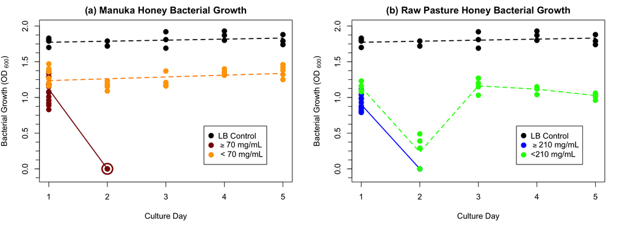

```r
lm.control.ttrend <- lm(OD ~ Culture, data = control.ttrend)
lines(control.ttrend$Culture, predict(lm.control.ttrend), lwd=2, lty = 2, col = "black")
```

Plotting glucose time trend

```r
glu.ttrend <- honeyGlu.d5[honeyGlu.d5$Trt == "Glu",]
glu6 <- glu.ttrend[glu.ttrend$Conc == 6,]
glu16 <- glu.ttrend[glu.ttrend$Conc == 16,]

plot(glu6$Culture, glu6$OD, ylim=c(-0.1,2), xlim = c(1,5), pch=16, col = "navyblue",cex = 2, ylab = "Bacterial Growth (Optical Density)", xlab = "Culture Day")
glu6.trend <- lm(OD ~ Culture, data = glu6)
lines(glu6$Culture, predict(glu6.trend), lwd=3, lty = 3, col ="navyblue")
```

```r
points(glu16$Culture, glu16$OD, pch=16, col = "blue", cex=2)
glu16.trend <- lm(OD ~ Culture, data = glu16)
lines(glu16$Culture, predict(glu16.trend), lwd=3, lty = 3, col ="blue")
```

```r
control.ttrend <- honeyGlu.d5.no.48[honeyGlu.d5.no.48$Trt == "Control",]
points(control.ttrend$Culture, control.ttrend$OD, pch=16, col = "black", cex=2)
lm.control.ttrend <- lm(OD ~ Culture, data = control.ttrend)
lines(control.ttrend$Culture, predict(lm.control.ttrend), lwd=3, lty = 3, col = "black")
```

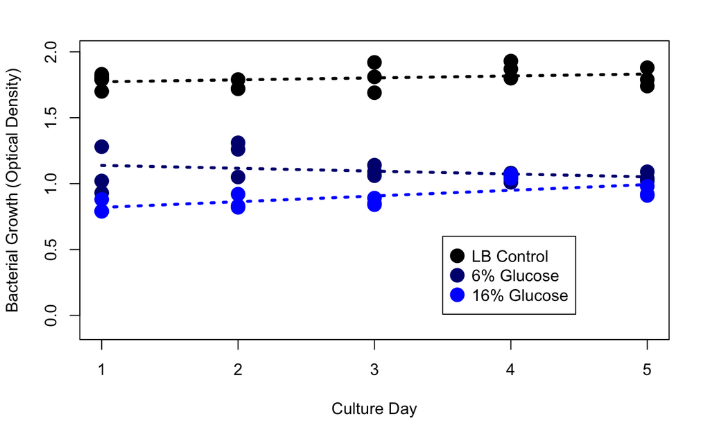

```r
legend(3.5,.6, pch = 16, col = c("black", "navyblue", "blue"),
       legend=c("LB Control","6% Glucose", "16% Glucose"), cex = 1, pt.cex = 2)
```

## Day 1-5 Analysis (but with control on all 13 days and no L180)

```r
alldata <- read.csv("Data/RawData.csv")
c13 <- alldata[alldata$Trt == "Control" & alldata$Solvent == "LB" & alldata$Day < 14,]
c13$OD.Hrs <- 24
c13[c13$Conc ==0 ,"predicted.osm"] <- 420
c13$Strain <- "Control"
c13$StrCon <- "Control"
c13$Trt <- c13$Trt[,drop=T]
honeyGlu.d5c13 <- honeyGlu.d5
honeyGlu.d5c13 <- honeyGlu.d5c13[honeyGlu.d5c13$Trt != "Control",]
honeyGlu.d5c13 <- rbind(honeyGlu.d5c13, c13)
honeyGlu.d5c13 <- honeyGlu.d5c13[honeyGlu.d5c13$StrCon != "Local180",]

tapply(honeyGlu.d5c13$OD, list(honeyGlu.d5c13$StrCon, honeyGlu.d5c13$Day), mean)
```

```
             1        2         3        4        5         6        7        8        9        10       11       12       13
Glu16       NA 0.820000 0.8566667 0.860000 1.056667 0.9366667       NA       NA       NA        NA       NA       NA       NA
Glu6        NA 1.076667 1.2066667 1.096667 1.043333 1.0500000       NA       NA       NA        NA       NA       NA       NA
Control  1.784 1.743333 1.8066667 1.866667 1.803333 1.7900000 1.166667 1.733333 1.686667 1.7766667 1.696667 1.726667 1.706667
Local140    NA       NA        NA       NA       NA        NA       NA       NA 1.165000 0.2933333 1.210000 1.093333 1.046667
Local160    NA       NA        NA       NA       NA        NA       NA 1.120000 0.145000 1.1150000 1.150000 1.006667       NA
Local180    NA       NA        NA       NA       NA        NA       NA       NA       NA        NA       NA       NA       NA
Local210    NA       NA        NA       NA       NA 1.0100000 0.000000 0.940000       NA        NA       NA       NA       NA
Local260 0.848 0.000000        NA 0.816000 0.000000        NA       NA       NA       NA        NA       NA       NA       NA
Manuka50    NA       NA        NA       NA       NA        NA 1.315000 1.175000 1.165000 1.3650000 1.440000       NA       NA
Manuka60    NA       NA        NA       NA       NA        NA 1.302000 1.156667 1.256667 1.3400000 1.316667       NA       NA
Manuka70    NA       NA        NA       NA 1.288000 0.0000000       NA       NA       NA        NA       NA       NA       NA
Manuka80 1.136 0.000000 0.9220000 0.000000       NA        NA       NA       NA       NA        NA       NA       NA       NA
```

### Combined Effect Analysis

Default: control as reference

```r
honeyGlu.d5c13$Day <- as.numeric(as.character(honeyGlu.d5c13$Day))
honeyGlu.d5c13$StrCon <- factor(honeyGlu.d5c13$StrCon)
honeyGlu.d5c13$StrCon <- relevel(honeyGlu.d5c13$StrCon, ref = "Control")
od.lm.control.5c13 <- lm(OD ~ Day + StrCon, data = honeyGlu.d5c13)
summary(od.lm.control.5c13)
```

```
Call:
lm(formula = OD ~ Day + StrCon, data = honeyGlu.d5c13)

Residuals:
     Min       1Q   Median       3Q      Max
-1.71297 -0.11215  0.04316  0.17356  0.71773

Coefficients:
               Estimate Std. Error t value Pr(>|t|)
(Intercept)     1.82868    0.10075  18.150  < 2e-16 ***
Day            -0.01653    0.01239  -1.334 0.183943
StrConGlu16    -0.85656    0.11504  -7.446 4.36e-12 ***
StrConGlu6     -0.66789    0.11504  -5.806 3.00e-08 ***
StrConLocal140 -0.71738    0.12849  -5.583 8.99e-08 ***
StrConLocal160 -0.74401    0.13110  -5.675 5.73e-08 ***
StrConLocal210 -1.11013    0.11608  -9.563  < 2e-16 ***
StrConLocal260 -1.36309    0.10956 -12.442  < 2e-16 ***
StrConManuka50 -0.38791    0.13171  -2.945 0.003673 **
StrConManuka60 -0.40615    0.10824  -3.752 0.000239 ***
StrConManuka70 -1.09376    0.12948  -8.447 1.18e-14 ***
StrConManuka80 -1.27285    0.11230 -11.335  < 2e-16 ***
---
Signif. codes:  0 ‘***’ 0.001 ‘**’ 0.01 ‘*’ 0.05 ‘.’ 0.1 ‘ ’ 1

Residual standard error: 0.3647 on 173 degrees of freedom
Multiple R-squared:  0.6267,    Adjusted R-squared:  0.603
F-statistic:  26.4 on 11 and 173 DF,  p-value: < 2.2e-16
```

Re-leveling the data with Glu6 as reference

```r
honeyGlu.d5c13$StrCon <- relevel(honeyGlu.d5c13$StrCon, ref = "Glu6")
od.lm.Glu6.5c13 <- lm(OD ~ Day + StrCon, data = honeyGlu.d5c13)
summary(od.lm.Glu6.5c13)
```

```
Call:
lm(formula = OD ~ Day + StrCon, data = honeyGlu.d5c13)

Residuals:
     Min       1Q   Median       3Q      Max
-1.71297 -0.11215  0.04316  0.17356  0.71773

Coefficients:
               Estimate Std. Error t value Pr(>|t|)
(Intercept)     1.16079    0.10641  10.909  < 2e-16 ***
Day            -0.01653    0.01239  -1.334  0.18394
StrConControl   0.66789    0.11504   5.806 3.00e-08 ***
StrConGlu16    -0.18867    0.13316  -1.417  0.15832
StrConLocal140 -0.04949    0.16417  -0.301  0.76345
StrConLocal160 -0.07611    0.16377  -0.465  0.64269
StrConLocal210 -0.44223    0.14261  -3.101  0.00225 **
StrConLocal260 -0.69520    0.12517  -5.554 1.04e-07 ***
StrConManuka50  0.27999    0.16125   1.736  0.08428 .
StrConManuka60  0.26174    0.14203   1.843  0.06707 .
StrConManuka70 -0.42587    0.15003  -2.839  0.00507 **
StrConManuka80 -0.60496    0.12594  -4.804 3.36e-06 ***
---
Signif. codes:  0 ‘***’ 0.001 ‘**’ 0.01 ‘*’ 0.05 ‘.’ 0.1 ‘ ’ 1

Residual standard error: 0.3647 on 173 degrees of freedom
Multiple R-squared:  0.6267,    Adjusted R-squared:  0.603
F-statistic:  26.4 on 11 and 173 DF,  p-value: < 2.2e-16
```

Re-leveling the data with Glu16 as reference

```r
honeyGlu.d5c13$StrCon <- relevel(honeyGlu.d5c13$StrCon, ref = "Glu16")
od.lm.Glu16.5c13 <- lm(OD ~ Day + StrCon, data = honeyGlu.d5c13)
summary(od.lm.Glu16.5c13)
```

```
Call:
lm(formula = OD ~ Day + StrCon, data = honeyGlu.d5c13)

Residuals:
     Min       1Q   Median       3Q      Max
-1.71297 -0.11215  0.04316  0.17356  0.71773

Coefficients:
               Estimate Std. Error t value Pr(>|t|)
(Intercept)     0.97212    0.10641   9.136  < 2e-16 ***
Day            -0.01653    0.01239  -1.334  0.18394
StrConGlu6      0.18867    0.13316   1.417  0.15832
StrConControl   0.85656    0.11504   7.446 4.36e-12 ***
StrConLocal140  0.13918    0.16417   0.848  0.39774
StrConLocal160  0.11255    0.16377   0.687  0.49285
StrConLocal210 -0.25357    0.14261  -1.778  0.07716 .
StrConLocal260 -0.50653    0.12517  -4.047 7.82e-05 ***
StrConManuka50  0.46865    0.16125   2.906  0.00414 **
StrConManuka60  0.45041    0.14203   3.171  0.00180 **
StrConManuka70 -0.23720    0.15003  -1.581  0.11569
StrConManuka80 -0.41630    0.12594  -3.306  0.00115 **
---
Signif. codes:  0 ‘***’ 0.001 ‘**’ 0.01 ‘*’ 0.05 ‘.’ 0.1 ‘ ’ 1

Residual standard error: 0.3647 on 173 degrees of freedom
Multiple R-squared:  0.6267,    Adjusted R-squared:  0.603
F-statistic:  26.4 on 11 and 173 DF,  p-value: < 2.2e-16
```

### Separating the effect of osmotic strength and antimicrobials d5

```r
honeyGlu.d5c13.no.control <- honeyGlu.d5c13[honeyGlu.d5c13$Trt != 'Control',]
lm.osm.trt.d5c13<- lm(OD ~ Day + Trt + predicted.osm, data = honeyGlu.d5c13.no.control)
summary(lm.osm.trt.d5c13)
```

```
Call:
lm(formula = OD ~ Day + Trt + predicted.osm, data = honeyGlu.d5c13.no.control)

Residuals:
     Min       1Q   Median       3Q      Max
-0.91515 -0.18079  0.09394  0.29401  0.62741

Coefficients:
                Estimate Std. Error t value Pr(>|t|)
(Intercept)    1.1188888  0.2657677   4.210 4.56e-05 ***
Day            0.0560467  0.0132498   4.230 4.22e-05 ***
TrtLocal      -0.4512176  0.1147447  -3.932 0.000132 ***
TrtManuka     -0.3391024  0.1180448  -2.873 0.004709 **
predicted.osm -0.0002985  0.0001939  -1.540 0.125935
---
Signif. codes:  0 ‘***’ 0.001 ‘**’ 0.01 ‘*’ 0.05 ‘.’ 0.1 ‘ ’ 1

Residual standard error: 0.417 on 139 degrees of freedom
Multiple R-squared:  0.2741,    Adjusted R-squared:  0.2532
F-statistic: 13.12 on 4 and 139 DF,  p-value: 4.309e-09
```

## Collected osmolality measures in lab… updated analysis

### Inputing osmolality measures into data

```r
newD5.osm <- honeyGlu.d5c13.no.control
newD5.osm$predicted.osm <- NULL
newD5.osm[newD5.osm$StrCon == "Manuka50" ,"osm"] <- 605
newD5.osm[newD5.osm$StrCon == "Manuka60" ,"osm"] <- 671
newD5.osm[newD5.osm$StrCon == "Manuka70" ,"osm"] <- 699.67
newD5.osm[newD5.osm$StrCon == "Manuka80" ,"osm"] <- 765.33
newD5.osm[newD5.osm$StrCon == "Local140" ,"osm"] <- 992.67
newD5.osm[newD5.osm$StrCon == "Local160" ,"osm"] <- 1090
newD5.osm[newD5.osm$StrCon == "Local180" ,"osm"] <- 1167.33
newD5.osm[newD5.osm$StrCon == "Local210" ,"osm"] <- 1323.33
newD5.osm[newD5.osm$StrCon == "Local260" ,"osm"] <- 1577.67
newD5.osm[newD5.osm$StrCon == "Glu6" ,"osm"] <- 802
newD5.osm[newD5.osm$StrCon == "Glu16" ,"osm"] <- 1494.5997


newD1.osm <- honeyGlu.d1.no.control
newD1.osm$predicted.osm <- NULL
newD1.osm[newD1.osm$StrCon == "Manuka50" ,"osm"] <- 605
newD1.osm[newD1.osm$StrCon == "Manuka60" ,"osm"] <- 671
newD1.osm[newD1.osm$StrCon == "Manuka70" ,"osm"] <- 699.67
newD1.osm[newD1.osm$StrCon == "Manuka80" ,"osm"] <- 765.33
newD1.osm[newD1.osm$StrCon == "Local140" ,"osm"] <- 992.67
newD1.osm[newD1.osm$StrCon == "Local160" ,"osm"] <- 1090
newD1.osm[newD1.osm$StrCon == "Local180" ,"osm"] <- 1167.33
newD1.osm[newD1.osm$StrCon == "Local210" ,"osm"] <- 1323.33
newD1.osm[newD1.osm$StrCon == "Local260" ,"osm"] <- 1577.67
newD1.osm[newD1.osm$StrCon == "Glu6" ,"osm"] <- 802
newD1.osm[newD1.osm$StrCon == "Glu16" ,"osm"] <- 1494.5997
```

### (Updated) Separation of the effect of osmotic strength and antimicrobials d5

```r
lm.newosm.trt.d5 <- lm(OD ~ Day + Trt + osm, data = newD5.osm)
summary(lm.newosm.trt.d5)
```

```
Call:
lm(formula = OD ~ Day + Trt + osm, data = newD5.osm)

Residuals:
     Min       1Q   Median       3Q      Max
-0.91761 -0.17561  0.09174  0.29640  0.62860

Coefficients:
              Estimate Std. Error t value Pr(>|t|)
(Intercept)  1.1094038  0.2630851   4.217 4.44e-05 ***
Day          0.0553233  0.0135622   4.079 7.58e-05 ***
TrtLocal    -0.4594371  0.1125830  -4.081 7.53e-05 ***
TrtManuka   -0.3413733  0.1194571  -2.858  0.00492 **
osm         -0.0002877  0.0001894  -1.519  0.13103
---
Signif. codes:  0 ‘***’ 0.001 ‘**’ 0.01 ‘*’ 0.05 ‘.’ 0.1 ‘ ’ 1

Residual standard error: 0.4171 on 139 degrees of freedom
Multiple R-squared:  0.2737,    Adjusted R-squared:  0.2528
F-statistic:  13.1 on 4 and 139 DF,  p-value: 4.439e-09
```

### (Updated) Separation of the effect of osmotic strength and antimicrobials d1

```r
lm.newosm.trt.d1 <- lm(OD ~ Day + Trt + osm, data = newD1.osm)
summary(lm.newosm.trt.d1)
```

```
Call:
lm(formula = OD ~ Day + Trt + osm, data = newD1.osm)

Residuals:
      Min        1Q    Median        3Q       Max
-0.300830 -0.048042  0.000058  0.075335  0.197397

Coefficients:
              Estimate Std. Error t value Pr(>|t|)
(Intercept)  1.3622929  0.1444425   9.431 2.05e-12 ***
Day          0.0196236  0.0082406   2.381 0.021353 *
TrtLocal     0.0264444  0.0702943   0.376 0.708465
TrtManuka    0.0117241  0.0650415   0.180 0.857727
osm         -0.0003947  0.0001097  -3.599 0.000766 ***
---
Signif. codes:  0 ‘***’ 0.001 ‘**’ 0.01 ‘*’ 0.05 ‘.’ 0.1 ‘ ’ 1

Residual standard error: 0.1134 on 47 degrees of freedom
Multiple R-squared:  0.6728,    Adjusted R-squared:  0.645
F-statistic: 24.17 on 4 and 47 DF,  p-value: 6.641e-11
```

### Updated Time Trends

```r
#tiff("./Final\ Figures/Fig.3.300.tiff", units = "in", width = 12, height = 3, res = 300)
par(mfrow = c(1,2))

Manuka.ttrend <- honeyGlu.d5.no.48[honeyGlu.d5.no.48$Trt == "Manuka",]
M80 <- Manuka.ttrend[Manuka.ttrend$Conc == 80,]
M70 <- Manuka.ttrend[Manuka.ttrend$Conc == 70,]
M60 <- Manuka.ttrend[Manuka.ttrend$Conc == 60,]
M50 <- Manuka.ttrend[Manuka.ttrend$Conc == 50,]

plot(M80$Culture, M80$OD, ylim=c(-0.1,2), xlim = c(1,5), pch=16, col = "darkorange4",cex = 1.5, ylab = expression("Bacterial Growth (OD "[600]*")"), xlab = "Culture Day", main = "(a) Manuka Honey")
minor.tick(nx = 0, ny=4, tick.ratio=0.75)
```

```r
M80.trend <- lm(OD ~ Culture, data = M80)
lines(M80$Culture, predict(M80.trend), lwd=2, lty=2, col ="darkorange4")

points(M70$Culture, M70$OD, pch=16, col = "darkorange", cex=1.5)
```

```r
M70.trend <- lm(OD ~ Culture, data = M70)
lines(M70$Culture, predict(M70.trend), lwd=2, lty=2, col = "darkorange")

points(M60$Culture, M60$OD, pch=16, col = "firebrick2", cex=1.5)
```

```r
M60.trend <- lm(OD ~ Culture, data = M60)
lines(M60$Culture, predict(M60.trend), lwd=2, lty=2, col = "firebrick2")

points(M50$Culture, M50$OD, pch=16, col = "goldenrod2", cex=1.5)
```

```r
M50.trend <- lm(OD ~ Culture, data = M50)
lines(M50$Culture, predict(M50.trend), lwd=2, lty=2, col = "goldenrod2")

control.ttrend <- honeyGlu.d5.no.48[honeyGlu.d5.no.48$Trt == "Control",]
points(control.ttrend$Culture, control.ttrend$OD, pch=16, col = "black", cex=1.5)
```

```r
lm.control.ttrend <- lm(OD ~ Culture, data = control.ttrend)
lines(control.ttrend$Culture, predict(lm.control.ttrend), lwd=2, lty = 2, col = "black")

symbols(x=2, y=0, circles=c(0.09), add=T, inches=F, fg = "darkorange4", lwd = 3)
```

```r
legend(4,.7, pch = 16, col = c("black", "darkorange4","darkorange", "firebrick2", "goldenrod2"),
       legend=c("LB Control", "80 mg/mL", "70 mg/mL", "60 mg/mL", "50 mg/mL"), cex = 1, pt.cex = 1.5)


#Local
local.ttrend <- honeyGlu.d5.no.48[honeyGlu.d5.no.48$Trt == "Local",]
L260 <- local.ttrend[local.ttrend$Conc == 260 & local.ttrend$Comments == "",]
L210 <- local.ttrend[local.ttrend$Conc == 210 & local.ttrend$Comments == "",]
L160 <- local.ttrend[local.ttrend$Conc == 160 & local.ttrend$Comments == "",]
L140 <- local.ttrend[local.ttrend$Conc == 140 & local.ttrend$Comments == "",]

plot(L260$Culture, L260$OD, ylim=c(-0.1,2), xlim = c(1,5), pch=16, col = "khaki4",cex = 1.5, ylab = expression("Bacterial Growth (OD "[600]*")"), xlab = "Culture Day", main = "(b) Raw Pasture Honey")
```

```r
minor.tick(nx = 0, ny=4, tick.ratio=0.75)
L260.trend <- lm(OD ~ Culture, data = L260)
lines(L260$Culture, predict(L260.trend), lwd=2, lty = 2, col ="khaki4")
```

```r
points(L210$Culture, L210$OD, pch=16, col = "khaki", cex=1.5)
L210.trend <- lm(OD ~ Culture, data = L210)
lines(L210$Culture, predict(L210.trend), lwd=2, lty = 2, col ="khaki")
```

```r
points(L160$Culture, L160$OD, pch=16, col = "lightseagreen", cex=1.5)
L160.avg <- tapply(L160$OD, L160$Culture, mean)
lines(c(1:5), L160.avg, lwd=2, lty=2, col = "lightseagreen")
```

```r
points(L140$Culture, L140$OD, pch=16, col = "darkgreen", cex=1.5)
L140.avg <- tapply(L140$OD, L140$Culture, mean)
lines(c(1:5), L140.avg, lwd=2, lty=2, col = "darkgreen")
```

```r
symbols(x=2, y=0, circles=c(0.09), add=T, inches=F, fg = "khaki", lwd = 3)

legend(4,.7, pch = 16, col = c("black", "khaki4", "khaki", "lightseagreen", "darkgreen"),
       legend=c("LB Control", "260 mg/mL", "210 mg/mL", "160 mg/mL", "140 mg/mL"), cex = 1, pt.cex = 1.5)
```

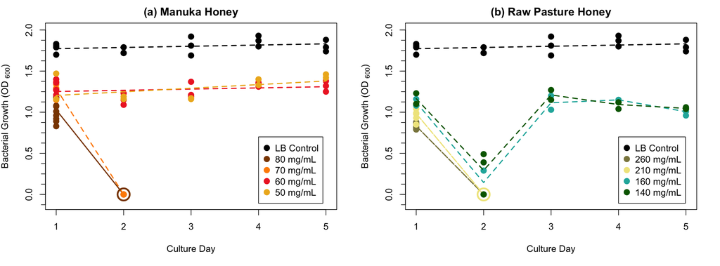

```r
control.ttrend <- honeyGlu.d5.no.48[honeyGlu.d5.no.48$Trt == "Control",]
points(control.ttrend$Culture, control.ttrend$OD, pch=16, col = "black", cex=1.5)
lm.control.ttrend <- lm(OD ~ Culture, data = control.ttrend)
lines(control.ttrend$Culture, predict(lm.control.ttrend), lwd=2, lty = 2, col = "black")
```